# Do more beautiful professors get better course evaluations?

Example Project Writeup

by Dr. Theobold

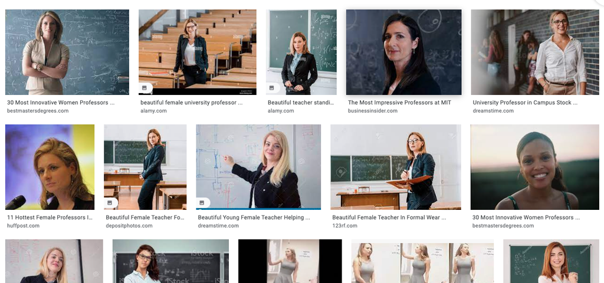

Google search results for “attractive professors”

## Data Description

Today, most colleges require the teaching of faculty to be evaluated through anonymous student evaluations. Historically, student evaluations date back to the 1920s, where faculty were in favor of this form of evaluation replacing the casual judgments of lone administrators. Faculty were largely dissatisfied with the alternatives, and eventually most accepted the premise of student evaluations. Professors today, however, look a lot different than professors in the 1920s or even the 1970s.

The data for this project come from end of semester student evaluations for a large sample of professors from The University of Texas at Austin. The original data set published in *Beauty in the Classroom* (Hamermesh & Parker, 2005) are available through the **openintro** R package.

I am interested in these data because I have read numerous papers on how teaching evaluations to be biased against women and people of color. Many of these papers, similar to the *Beauty in the Classroom* article, propose that student evaluations often reflect biases in favor of non-teaching related characteristics, such as the physical appearance of the instructor. These data allow for me to explore the relationship between professor’s attractiveness and their teaching evaluations.

For this project, I will focus on two variables: the average attractiveness of the professor and the professor’s average course evaluation score. The study had six students rate the attractiveness of each professor based on their picture from 1 (lowest) to 10 (highest). The average of these six scores is the variable used for this project.

## Data Visualization

### Histogram of Average Teaching Evalution Scores

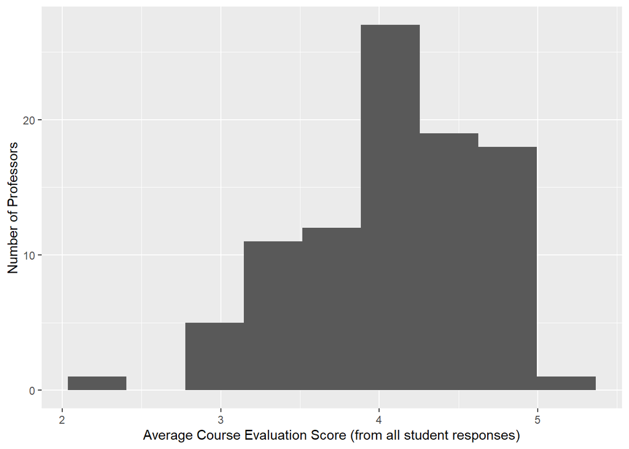

### Histogram of Average Attractiveness Scores

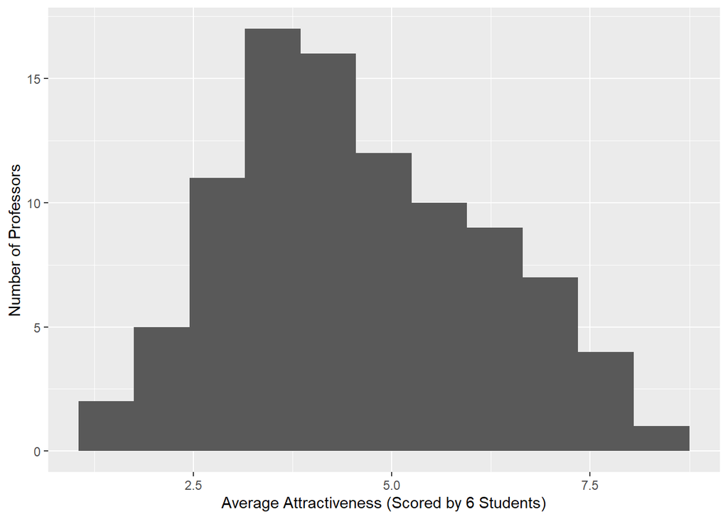

In the histogram of attractiveness scores, we see a unimodal distribution with a slight right skew. The majority of professors received an average attractiveness score of about 4. There were a few professors who received low attractiveness scores of about 2, but I would not consider these outliers as they are not far from the center of the distribution. However, there are professors who received average attractiveness scores of over 7.5, which I would classify as potential outliers, as they are quite far from the center of the distribution.

### Scatterplot of Avearge Beauty Score and Average Course Evalution Score

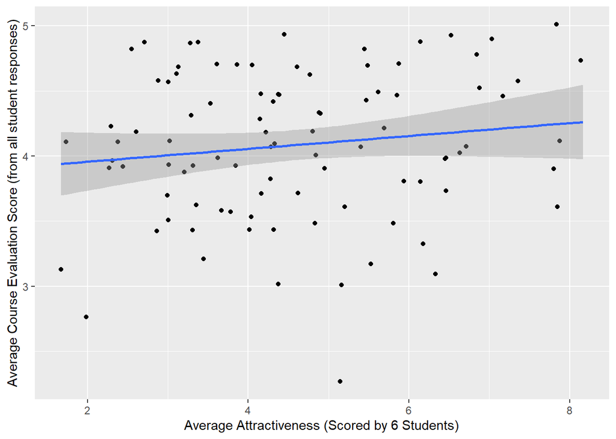

In the scattterplot we see a positive relationship between professor’s attractiveness and their course evaluation score. The relationship is weak to moderate, as there is a great deal of variability in course evaluation scores across all levels of attractiveness. This variability makes it more difficult to say the shape of the relationship, but I would say there is a weak linear relationship between these two variables. Finally, there are a few outliers, namely the professors with course evaluation scores under 3 and attractiveness scores below 2. These are both far from the center (high leverage) and far from the regression line, which suggests they may be quite influential.

Beauty Score

### Model Conditions

There are four conditions required to be verified before we perform inference on the linear relationship between these two variables. These conditions are: linearity of the relationship, independence of observations, nearly normal residuals, and constant variability.

**Linearity:** As seen in the scatterplot above, the relationship between average course evaluation score and average beauty score is weakly linear. Although the relationship is not very strong, it does not appear that there is evidence of a non-linear (e.g., quadratic, logarithmic) relationship.

**Independence:** These data were from a convenience sample of professors at the University of Texas at Austin. The researchers obtained the course evaluation scores for every professor in the sample, for every course they taught. Thus, for some professors there were multiple observations.

Having multiple observations for each professor violates the independence condition. Thus, for each professor I randomly selected **one** of their courses. After removing these repeated observations, I no longer believe the independence condition is violated. There is no reason to believe that knowing the evaluation score of one professor should give me perfect information about another professor’s evaluation score.

**Normality of Residuals:** The condition of normality can be checked using either the distribution of the responses (average evaluation scores) or the distribution of residuals from the regression model. Based on the histogram above, it does not appear that the condition of nearly normal responses is violated. While the distribution has a slight left skew, the sample size is 94 professors, well over the threshold of 60 for substantially skewed distributions.

**Equal Variance:** The variability of the evaluation scores appears similar across the regression line. While there is a larger spread in the evaluation scores for professors with beauty ratings between 4 and 5, the size of these differences is not large. Instead, across all beauty ratings, it appears that course evaluation scores vary from about 3 to about 5.

Since I have not seen any major violations of these conditions, I believe using t-based methods will not incorrectly estimate a p-value or confidence interval.

### Coefficient Estimates

| term | estimate | std_error | statistic | p_value | lower_ci | upper_ci |
| --- | --- | --- | --- | --- | --- | --- |
| intercept | 3.858 | 0.179 | 21.559 | 0.000 | 3.560 | 4.155 |
| bty_avg | 0.049 | 0.037 | 1.345 | 0.182 | -0.012 | 0.111 |